# Distribution of Personal Income in Maine

Part 1 of 3: Understanding how personal income is shared across household quintiles and by income components

How much money flows into Maine households, and who gets what share? New data released July 10, 2025, by the U.S. Bureau of Economic Analysis (BEA) offers a snapshot of how personal income spreads across communities statewide – *this is part one of a three-part series that explores personal income distribution in Maine.*

Part 1 focuses on understanding how personal income - and its components - are defined and how it is shared across household quintiles and by income components in Maine.

## What is Personal Income?

1

Personal Income Definition

The Bureau of Economic Analysis (BEA) defines personal income as *“income that people get from wages and salaries, Social Security and other government benefits, dividends and interest, business ownership, and other sources.”* This differs from other commonly used income measures, like median household income, that include only money income.

Personal income is comprised of six major components:

Wages & Salaries

Employment income from jobs

Proprietors’ Income

Self-employment and business income

Rental Income

Income from property rentals

Personal Dividends

Stock dividend payments

Personal Interest

Interest from savings, bonds

Transfer Receipts

Government payments (Social Security, unemployment, etc.)

## Understanding Quintiles and Income Distribution

2

Understanding Quintiles & Income Distribution

To better understand how this income is shared across households, the BEA groups households into quintiles. Quintiles divide all households into five equal-sized groups (each representing 20% of the population), ranked from the lowest to the highest income:

1st Quintile

0-20%

2nd Quintile

20-40%

3rd Quintile

40-60%

4th Quintile

60-80%

5th Quintile

80-100%

These breakouts help illustrate how income is distributed across different income levels.

- The **first quintile** includes the 20% of households with the lowest income.
- The **second quintile** represents households in the lower-middle (20th – 40th) income percentiles.
- The **third quintile** includes households in the middle (40th – 60th) income percentiles.
- The **fourth quintile** represents households in the upper-middle (60th – 80th) income percentiles.
- The **fifth quintile** includes the top 20% of households with the highest income.

The share of total personal income by income quintile is illustrated below:

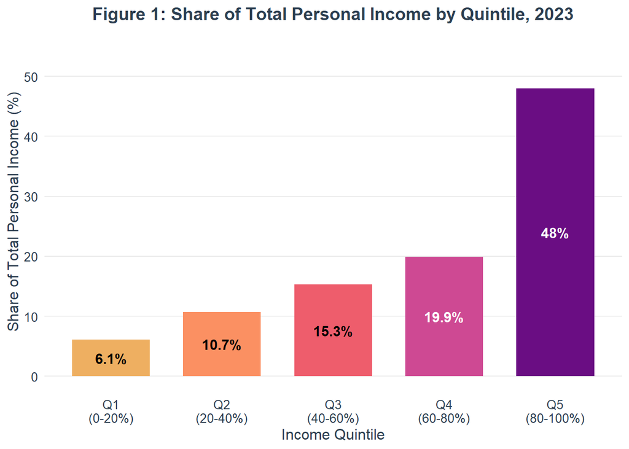

Key Insight:

In 2023, the 20% of Maine households with the highest income received 48.0% of total personal income. The 20% of households with the lowest income received 6.1%. This distribution shows how income is shared across different income levels.

## Distribution of Personal Income by Component

3

Distribution of Personal Income by Component

The BEA provides estimates of the distribution of income received by component of personal income. Components of personal income include:

Net Earnings

Wages and salaries, employer-paid benefits (such as health insurance and retirement contributions), and income from self-employment

Dividends and Interest

Income from owning financial assets, such as stocks, bonds, and savings accounts

Rental Income

Net income earned from rental properties, as well as royalties from intellectual properties or natural resources (e.g., patents or oil rights)

Personal Current Transfer Receipts

Income payments to persons for which no services are performed, including government social benefits like Social Security income and Medicare

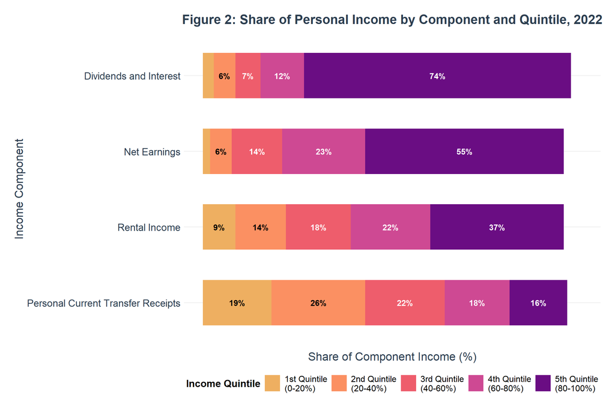

Key Patterns:

The distribution of personal income components varies across income groups. The top 20% of Maine households received 74% of all dividends and interest income. In contrast, transfer receipts were more evenly spread across income quintiles with the largest share (26%) going to households in the lower-middle (20th – 40th) income percentiles.

## Distribution with Interactive Income Flow

4

Income Component Flows Across Quintiles

See how each income component flows differently across household income levels. Click on any segment to see detailed information about that quintile and income source.

Q1 (0-20%)  
Lowest Income

Q2 (20-40%)  
Lower-Middle Income

Q3 (40-60%)  
Middle Income

Q4 (60-80%)  
Upper-Middle Income

Q5 (80-100%)  
Highest Income

**Total Personal Income**  
All sources combined

6.1%

10.7%

15.3%

19.9%

48.0%

Dividends and Interest  
Financial asset income

3%

6%

7%

12%

74%

Net Earnings  
Wages, salaries, benefits

2%

6%

14%

23%

55%

Rental Income  
Property & royalties

9%

14%

18%

22%

37%

Personal Current Transfer Receipts  
Government benefits

19%

26%

22%

18%

16%

Key Patterns to Notice:

**Investment Concentration:** 74% of dividends & interest goes to the highest income quintile (80-100%), while only 3% goes to the lowest.  
**Transfer Balance:** Government transfers provide crucial support - 26% goes to lower-middle income households (20-40%), with 19% to the lowest quintile.  
**Earnings Distribution:** Net earnings show extreme concentration - 55% go to the top quintile, with only 2% to the bottom quintile.  
**Overall Result:** The top quintile receives 48.0% of all personal income while the bottom receives only 6.1%.